# Chapter 2 — Describing and Presenting Data (R companion)

R/tidyverse translation of *Understanding Data by Alan Garfinkel and Yina Guo

Adrian Soto-Mota, MD, PhD, FACP.

2026-04-24

# Orientation

Chapter 2 (book pp. 23–102) is about **looking at data** before testing anything. The core claim: summary statistics (mean, SD) hide the structure that dot plots, histograms, and KDEs reveal. The book contains **no Python code listings** in this chapter, only figures. This companion reproduces every visualization style the chapter discusses, then shows the mechanical definitions of mean, median, SD, SEM, IQR, etc., with small worked examples.

# A running data set

Throughout the chapter, simulated biological measurements (e.g., T-cell counts) are used. We’ll construct a similar example: two groups, 30 observations each, drawn from distributions that look different but have similar means.

```r
n <- 30
df <- tibble(
  group = rep(c("Control", "Treatment"), each = n),
  value = c(
    rnorm(n, mean = 10, sd = 2),                  # Control: tight, symmetric
    c(rnorm(n - 3, mean = 9, sd = 1.2),           # Treatment: mostly tight
      rnorm(3, mean = 16, sd = 0.5))              # ...with 3 high outliers
  )
)
head(df)
```

```
## # A tibble: 6 x 2
##   group   value
##   <chr>   <dbl>
## 1 Control  8.75
## 2 Control 10.4
## 3 Control  8.33
## 4 Control 13.2
## 5 Control 10.7
## 6 Control  8.36
```

# §2.1 — Dot plots and beeswarm plots *(book p. 25)*

Chapter rule: **show every observation**.

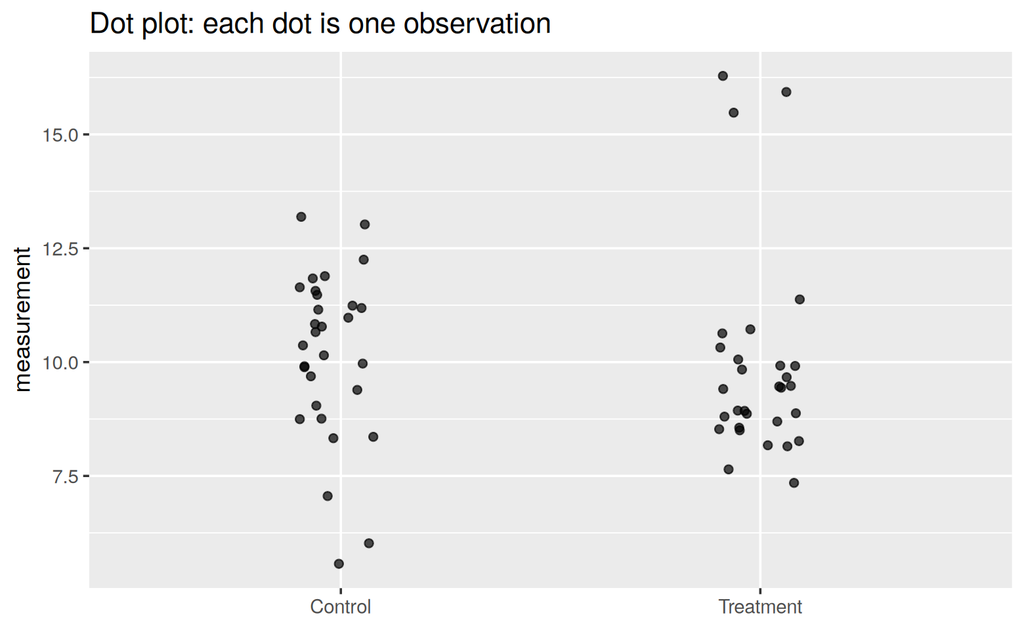

```r
ggplot(df, aes(x = group, y = value)) +
  geom_jitter(width = 0.1, height = 0, alpha = 0.7) +
  labs(title = "Dot plot: each dot is one observation",
       x = NULL, y = "measurement")
```

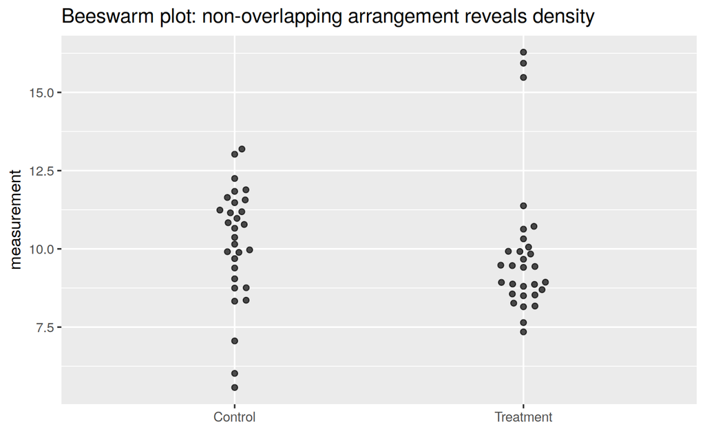

```r
ggplot(df, aes(x = group, y = value)) +
  geom_beeswarm(cex = 2, alpha = 0.7) +
  labs(title = "Beeswarm plot: non-overlapping arrangement reveals density",
       x = NULL, y = "measurement")
```

The beeswarm makes it obvious that the Treatment group has a small high-value tail — something a mean would wash out.

# §2.2 — Histograms and kernel density estimates *(book p. 33)*

## Histograms

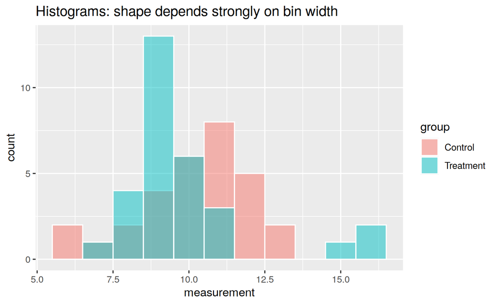

```r
ggplot(df, aes(value, fill = group)) +
  geom_histogram(binwidth = 1, color = "white",
                 position = "identity", alpha = 0.5) +
  labs(title = "Histograms: shape depends strongly on bin width",
       x = "measurement", y = "count")
```

**Try different bin widths** — this is the chapter’s warning:

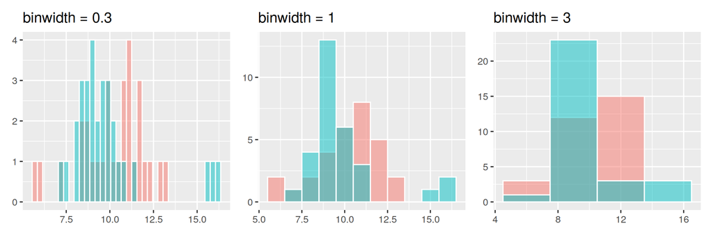

```r
bw_examples <- c(0.3, 1, 3)
map(bw_examples, \(bw) {
  ggplot(df, aes(value, fill = group)) +
    geom_histogram(binwidth = bw, color = "white",
                   position = "identity", alpha = 0.5) +
    labs(title = paste("binwidth =", bw), x = NULL, y = NULL) +
    theme(legend.position = "none")
}) |> patchwork::wrap_plots(nrow = 1)
```

## Kernel density estimates

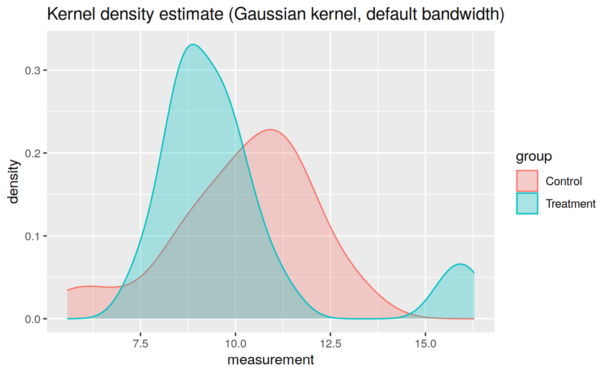

```r
ggplot(df, aes(value, fill = group, color = group)) +
  geom_density(alpha = 0.3) +
  labs(title = "Kernel density estimate (Gaussian kernel, default bandwidth)",
       x = "measurement", y = "density")
```

The book warns that **bandwidth matters as much as bin width did**:

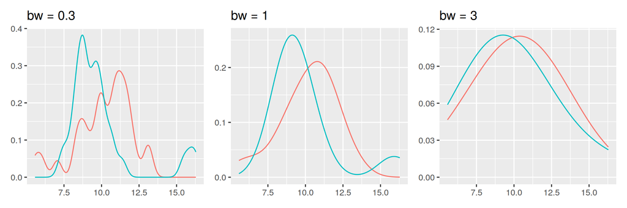

```r
bws <- c(0.3, 1, 3)
map(bws, \(b) {
  ggplot(df, aes(value, color = group)) +
    geom_density(bw = b) +
    labs(title = paste("bw =", b), x = NULL, y = NULL) +
    theme(legend.position = "none")
}) |> patchwork::wrap_plots(nrow = 1)
```

# §2.3 — Measures of central tendency *(book p. 61)*

Build them from scratch so the definitions are not black boxes.

```r
x <- df$value[df$group == "Treatment"]

# Mean: Σx / n
manual_mean   <- sum(x) / length(x)

# Median: middle of the sorted sample (or mean of two middles)
sorted_x <- sort(x)
m <- length(sorted_x)
manual_median <- if (m %% 2 == 1) {
  sorted_x[(m + 1) / 2]
} else {
  mean(sorted_x[c(m / 2, m / 2 + 1)])
}

# Mode: the "most common" value — for continuous data, peak of the KDE
d <- density(x)
manual_mode <- d$x[which.max(d$y)]

c(manual_mean = manual_mean, builtin_mean = mean(x),
  manual_median = manual_median, builtin_median = median(x),
  approx_mode = manual_mode)
```

```
##    manual_mean   builtin_mean  manual_median builtin_median    approx_mode
##       9.873550       9.873550       9.423421       9.423421       8.881137
```

## The “Flaw of Averages” *(book §2.3, p. 66)*

```r
river <- c(rep(0.3, 19), 4.0)   # 20 depth readings
mean(river)                      # Mean depth = 0.485 m
```

```
## [1] 0.485
```

```r
max(river)                       # Maximum depth = 4 m — the mean is misleading
```

```
## [1] 4
```

# §2.4 — Measures of variability *(book p. 77)*

```r
# Variance and SD using the classical n−1 denominator
manual_var <- sum((x - mean(x))^2) / (length(x) - 1)
c(manual_var = manual_var, builtin_var = var(x),
  manual_sd  = sqrt(manual_var), builtin_sd = sd(x))
```

```
##  manual_var builtin_var   manual_sd  builtin_sd
##    5.010758    5.010758    2.238472    2.238472
```

```r
# Standard error of the mean: SD / sqrt(n)
sem <- sd(x) / sqrt(length(x))
sem
```

```
## [1] 0.4086872
```

```r
# Median absolute deviation — robust alternative
mad_x <- median(abs(x - median(x)))
c(manual_mad = mad_x, builtin_mad = mad(x, constant = 1))
```

```
##  manual_mad builtin_mad
##   0.7957709   0.7957709
```

```r
# IQR and range
quantile(x, c(0.25, 0.75))
```

```
##       25%       75%
##  8.593492 10.023557
```

```r
IQR(x)
```

```
## [1] 1.430065
```

```r
range(x)
```

```
## [1]  7.347529 16.284860
```

```r
diff(range(x))
```

```
## [1] 8.937331
```

# §2.5 — Presentation: show the data *(book p. 84)*

The chapter shows how bar graphs with error bars (“dynamite plunger plots”, are a dab idea §2.5, p. 93) as they hide the distribution. Compare:

[figure not shown]

```r
summary_df <- df |>
  group_by(group) |>
  summarise(mean = mean(value),
            sem  = sd(value) / sqrt(n()), .groups = "drop")

bad <- ggplot(summary_df, aes(group, mean)) +
  geom_col(fill = "steelblue", width = 0.5) +
  geom_errorbar(aes(ymin = mean - sem, ymax = mean + sem), width = 0.1) +
  labs(title = "Bad: 'Dynamite plunger' bar graph — hides the distribution",
       x = NULL, y = "value")

good <- ggplot(df, aes(group, value)) +
  geom_beeswarm(alpha = 0.6) +
  stat_summary(fun = mean, geom = "crossbar",
               width = 0.4, color = "red") +
  labs(title = "Good: beeswarm + mean crossbar — every observation visible",
       x = NULL, y = "value")

patchwork::wrap_plots(bad, good, nrow = 1)
```

Box plots are acceptable but still hide modality:

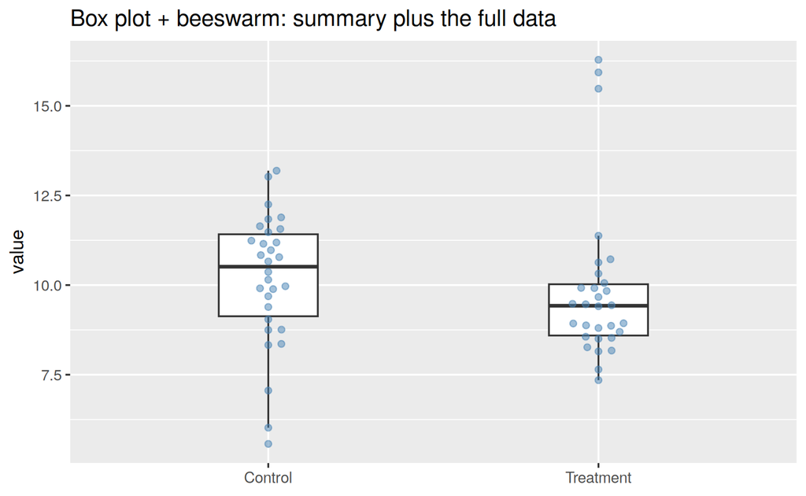

```r
ggplot(df, aes(group, value)) +
  geom_boxplot(width = 0.3, outlier.shape = NA) +
  geom_beeswarm(alpha = 0.5, cex = 2, color = "steelblue") +
  labs(title = "Box plot + beeswarm: summary plus the full data",
       x = NULL, y = "value")
```

This is the layout the chapter recommends: a summary layer on top of a plot that shows every observation.

# Exercises for students

1. Change `set.seed(1)` to your student ID. Regenerate the beeswarm. Is the 3-outlier pattern in the Treatment group still visible? Explain why a bar graph would fail to reveal it.
2. Replace `binwidth = 1` in the first histogram with `bins = 5`, `bins = 30`, and `bins = 100`. Which bin count best represents the underlying distribution?
3. Use `rlnorm(50, meanlog = 0, sdlog = 1)` to generate a skewed sample. Compare the mean, median, and mode. Which one best describes a “typical” value?